# Case 4: Global Handel

Verdensbanken er en internasjonal institusjon som gir lån og teknisk bistand til utviklingsland for å bekjempe fattigdom og fremme økonomisk vekst. Norge har vært med siden starten i 1944. Du kan lese mer om [Verdensbanken her](https://www.fn.no/om-fn/fns-organisasjoner-fond-og-programmer/verdensbanken). Verdensbanken samler også inn data på ulike økonomiske indikatorer. En oversikt over ulike indikatorer på global utvikling finner du [her](https://data.worldbank.org/indicator?tab=all).

Vi skal benytte oss a [pakken `WDI`](https://vincentarelbundock.github.io/WDI/) som gjør det mulig for oss å laste ned data via kode.

Vi laster nødvendige pakker.

```r
library(WDI)
library(tidyverse)
```

## Import

Vi gjør et søk på nøkkelordet `imports`.

```r
imports <- WDIsearch('imports') %>% as_tibble()
imports
```

```
# A tibble: 117 x 2
   indicator        name
   <chr>            <chr>
 1 1600000          1600000:BALANCE OF EXPORTS AND IMPORTS
 2 AG.IMP.CREL.MT   Cereal imports (metric tons)
 3 BM.AG.FRST.CD    Forest products imports (FAO, current US$)
 4 BM.AG.HZ.PEST.CD Hazardous pesticides imports (FAO, current US$)
 5 BM.AG.PEST.CD    Pesticides imports (FAO, current US$)
 6 BM.FOD.AGRI.CD   Food imports excluding fish (FAO, current US$)
 7 BM.GSR.AGRI.CD   Total agricultural imports (FAO, current US$)
 8 BM.GSR.CMCP.ZS   Communications, computer, etc. (% of service imports, BoP)
 9 BM.GSR.COMM.CD   Communications services, imports (BoP, current US$)
10 BM.GSR.FINS.CD   Financial services, imports (BoP, current US$)
# … with 107 more rows
```

Vi ser at vi får 117 indikatorer som inneholder `imports` i beskrivelsen. Vi ønsker å benytte oss av indikatoren [“Imports of goods and services (current US$)”](https://data.worldbank.org/indicator/NE.IMP.GNFS.CD). Denne har forkortelsen *NE.IMP.GNFS.CD*. Følgende informasjon er tilgjengelig om denne tabellen.

```
Imports of goods and services represent the value of all goods and other market services received from the rest of the world. They include the value of merchandise, freight, insurance, transport, travel, royalties, license fees, and other services, such as communication, construction, financial, inf…
```

Vi lagrer tabellen i objektet `df_import`.

```r
df_import <- WDI(indicator = "NE.IMP.GNFS.CD", country = "all")
head(df_import)
```

```
  iso2c                     country NE.IMP.GNFS.CD year
1    ZH Africa Eastern and Southern   225165427091 2020
2    ZH Africa Eastern and Southern   275475737179 2019
3    ZH Africa Eastern and Southern   285548049881 2018
4    ZH Africa Eastern and Southern   267094876705 2017
5    ZH Africa Eastern and Southern   246772253288 2016
6    ZH Africa Eastern and Southern   283616797456 2015
```

Vi kan nå se nærmere på importen til Norge. Enheten settes til milliarder ($10^9$) dollar.

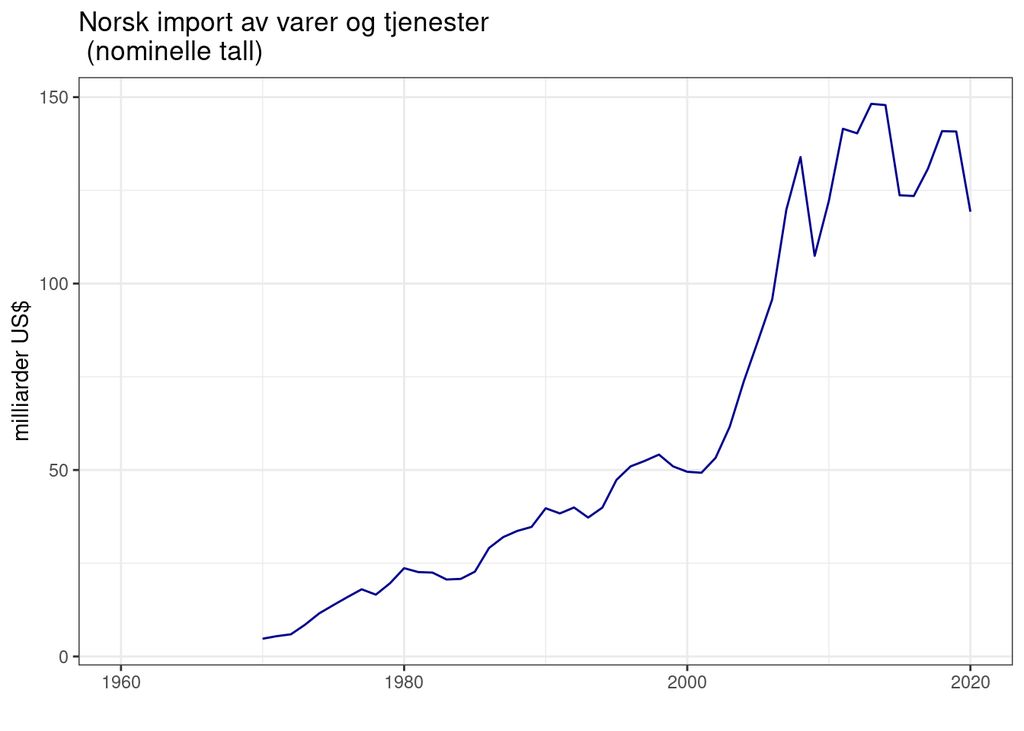

```r
df_import %>%
  filter(country=="Norway") %>%
  rename(import=NE.IMP.GNFS.CD,
         år=year) %>%
  mutate(import=import/1e9) %>%
  ggplot(aes(x=år, y=import)) +
  geom_line(col="dark blue") +
  labs(title="Norsk import av varer og tjenester \n (nominelle tall)",
       x =" ",
       y = "milliarder US$") +
  theme_bw()
```

### Oppgave 1

Beregn prosentvis endring i import fra ett år til det neste. Mellom hvilke år var det størst økning/nedgang?

## Eksport

Vi gjør deretter et søk på eksport.

```r
exports <- WDIsearch('exports') %>% as_tibble()
exports
```

```
# A tibble: 150 x 2
   indicator         name
   <chr>             <chr>
 1 1600000           1600000:BALANCE OF EXPORTS AND IMPORTS
 2 BM.AG.AGR.TRAC.CD Agricultural tractors, exports (FAO, current US$)
 3 BM.AG.AGR.TRAC.NO Agricultural tractors, exports
 4 BM.AG.CREL.CD     Cereal exports (FAO, current US$)
 5 BM.AG.CREL.MT     Cereal exports quantity (FAO, tonnes)
 6 BX.AG.FRST.CD     Forest products exports (FAO, current US$)
 7 BX.AG.HZ.PEST.CD  Hazardous pesticides exports (FAO, current US$)
 8 BX.AG.PEST.CD     Pesticides exports (FAO, current US$)
 9 BX.FOD.AGRI.CD    Food exports excluding fish (FAO, current US$)
10 BX.GSR.AGRI.CD    Total agricultural exports (FAO, current US$)
# … with 140 more rows
```

Her er det hele 150 indikatorer som inneholder `exports` i beskrivelsen. Denne gangen ønsker å benytte oss av indikatoren “Exports of goods and services (current US$)”. Denne har forkortelsen *NE.EXP.GNFS.CD*. Følgende informasjon er tilgjengelig om denne tabellen.

```
Exports of goods and services represent the value of all goods and other market services provided to the rest of the world. They include the value of merchandise, freight, insurance, transport, travel, royalties, license fees, and other services, such as communication, construction, financial, infor…
```

Vi lagrer tabellen i objektet `df_export`.

```r
df_export <- WDI(indicator = "NE.EXP.GNFS.CD", country = "all")
head(df_export)
```

```
  iso2c                     country NE.EXP.GNFS.CD year
1    ZH Africa Eastern and Southern   204148784649 2020
2    ZH Africa Eastern and Southern   243105549810 2019
3    ZH Africa Eastern and Southern   257331005512 2018
4    ZH Africa Eastern and Southern   236771709409 2017
5    ZH Africa Eastern and Southern   205797036899 2016
6    ZH Africa Eastern and Southern   222053253203 2015
```

Vi kan nå se nærmere på eksporten fra Norge. Enheten settes til milliarder ($10^9$) dollar.

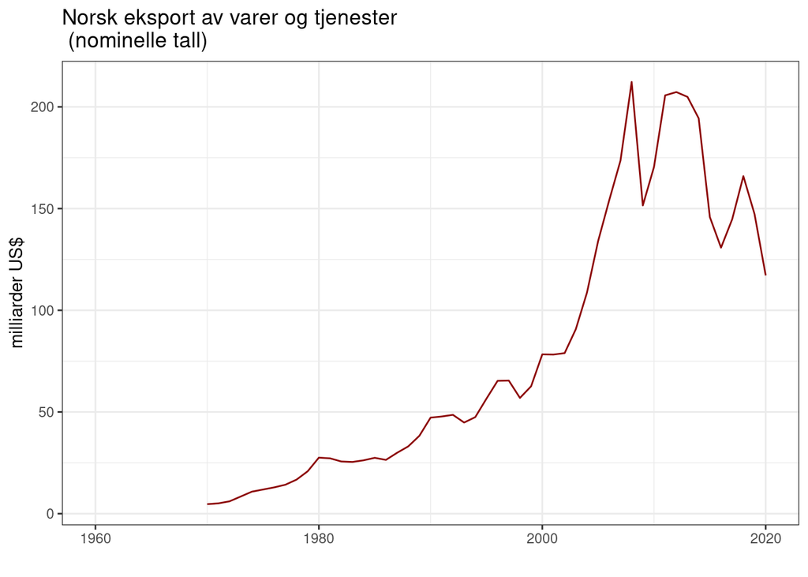

```r
df_export %>%
  filter(country=="Norway") %>%
  rename(eksport=NE.EXP.GNFS.CD,
         år=year) %>%
  mutate(eksport=eksport/1e9) %>%
  ggplot(aes(x=år, y=eksport)) +
  geom_line(col="dark red") +
  labs(title="Norsk eksport av varer og tjenester \n (nominelle tall)",
       x =" ",
       y = "milliarder US$") +
  theme_bw()
```

### Oppgave 2

Beregn prosentvis endring i eksport fra ett år til det neste. Mellom hvilke år var det størst økning/nedgang? Følger endringer i eksport og import det samme mønsteret?

## Import og eksport sett i sammenheng

Dersom vi ønsker å se import og eksport i sammengeng må vi slå de to tabellene sammen. Dette kan gjøres med funksjonen `dplyr::left_join()`. Vi spesifiserer også hvilke variabler som er felles for de to datasettene med opsjonen `by=`. For akkurat denne funksjonen trenger vi ikke ha med `by=`, men vi tar den med for lesbarhetens skyld.

```r
dframe <- left_join(df_import, df_export, by = c("iso2c", "country", "year"))
head(dframe)
```

```
  iso2c                     country NE.IMP.GNFS.CD year NE.EXP.GNFS.CD
1    ZH Africa Eastern and Southern   225165427091 2020   204148784649
2    ZH Africa Eastern and Southern   275475737179 2019   243105549810
3    ZH Africa Eastern and Southern   285548049881 2018   257331005512
4    ZH Africa Eastern and Southern   267094876705 2017   236771709409
5    ZH Africa Eastern and Southern   246772253288 2016   205797036899
6    ZH Africa Eastern and Southern   283616797456 2015   222053253203
```

Vi fortsetter med å se nærmere på Norge. Vi endrer formatet på tabellen til “langt” gjennom å benytte funksjonen `pivot_longer()`. Dermed kan vi indeksere kategoriene enklere.

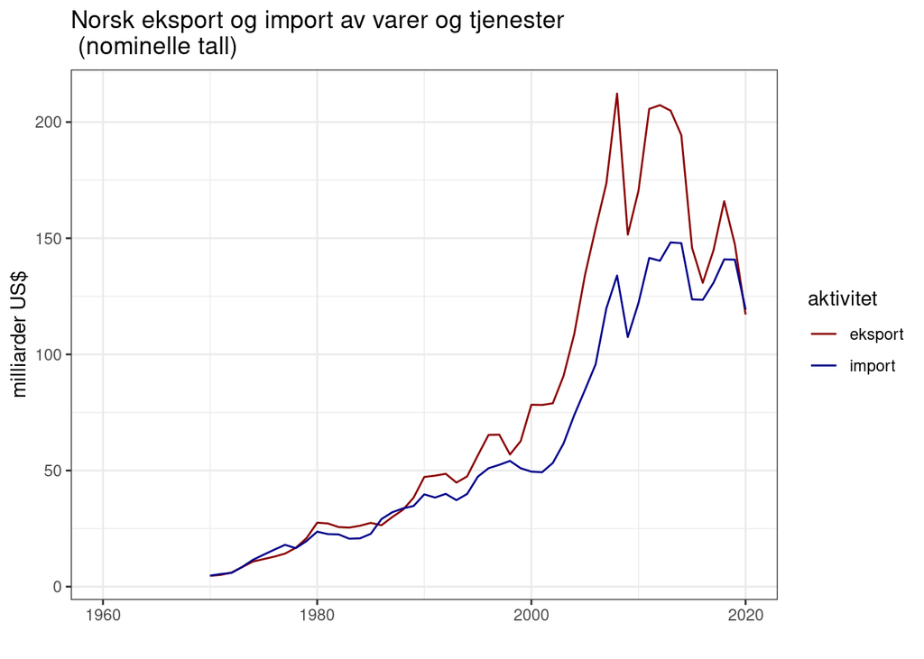

```r
dframe %>%
  filter(country=="Norway") %>%
  rename(import=NE.IMP.GNFS.CD,
         eksport=NE.EXP.GNFS.CD,
         år=year) %>%
  mutate(import=import/1e9,
         eksport=eksport/1e9) %>%
  select(år, import, eksport) %>%
  pivot_longer(-år, names_to="aktivitet", values_to="verdi") %>%
  ggplot(aes(x=år, y=verdi, col=aktivitet)) +
  geom_line() +
  scale_color_manual(values=c("dark red", "dark blue")) +
  labs(title="Norsk eksport og import av varer og tjenester \n (nominelle tall)",
       x =" ",
       y = "milliarder US$") +
  theme_bw()
```

## Sammenligne to land

Dersom vi ønsker å sammenligne eksportverdiene til to land kan vi benytte følgende kode. Legg merke til at vi benytter `filter()` og angir de to landene i en vektor med å benytte `%in%`.

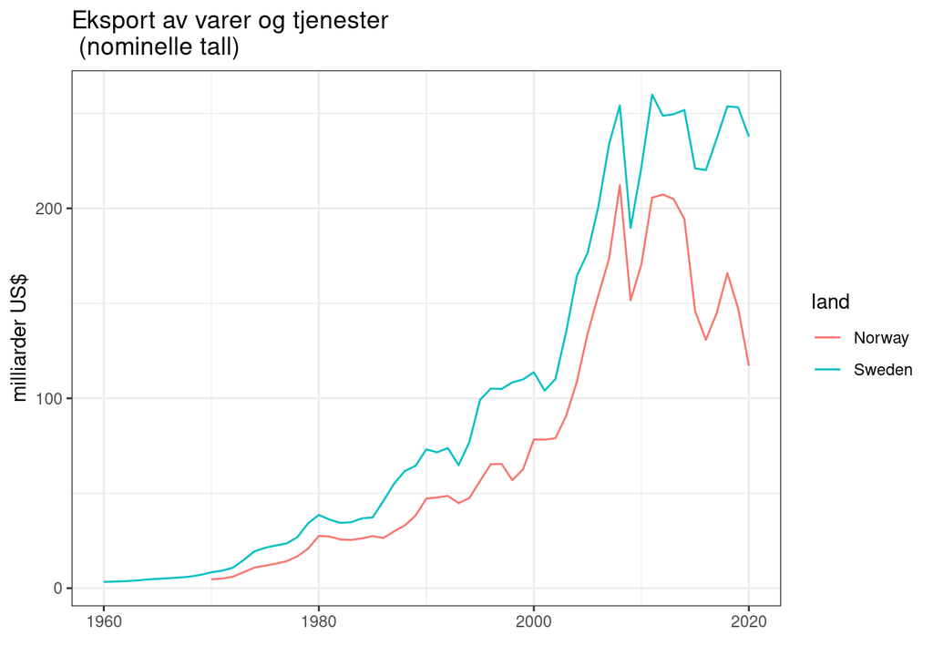

```r
df_export %>%
  filter(country %in% c("Norway","Sweden")) %>%
  rename(eksport=NE.EXP.GNFS.CD,
         land=country,
         år=year) %>%
  mutate(eksport=eksport/1e9) %>%
  ggplot(aes(x=år, y=eksport, col=land)) +
  geom_line() +
  labs(title="Eksport av varer og tjenester \n (nominelle tall)",
       x =" ",
       y = "milliarder US$") +
  theme_bw()
```

### Oppgave 3

Benytt funksjonen `dplyr::recode()` til å endre til norske landnavn i figuren over.

### Oppgave 4

Lag en figur som viser den kumulative prosentvise endringen i eksport og import for Norge og Sverige.

## `R` kode fra dette caset

```r
getwd()
setwd("~/undervisning/SOK1004")
knitr::purl("case_4_global_handel.Rmd")
```